# Machine learning Labwork 1

## Loading data

```r
url <- "https://raw.githubusercontent.com/xdhao/solarRadPredict/main/SolarPrediction.csv"
SolarPrediction <- read.csv(url)
```

#### Solar Radiation

These datasets are meteorological data from the HI-SEAS weather station from four months (September through December 2016) between Mission IV and Mission V.

For each dataset, the fields are:

A row number (1-n) useful in sorting this export’s results The UNIX time_t date (seconds since Jan 1, 1970). Useful in sorting this export’s results with other export’s results The date in yyyy-mm-dd format The local time of day in hh:mm:ss 24-hour format The numeric data, if any (may be an empty string) The text data, if any (may be an empty string)

The units of each dataset are:

1. Solar radiation: watts per meter^2
2. Temperature: degrees Fahrenheit
3. Humidity: percent
4. Barometric pressure: Hg
5. Wind direction: degrees
6. Wind speed: miles per hour
7. Sunrise/sunset: Hawaii time

## General dataset parameters

#### First 5 rows

```r
library(knitr)
kable(SolarPrediction[1:5,], caption = "dataset parameters")
```

dataset parameters

| UNIXTime | Data | Time | Radiation | Temperature | Pressure | Humidity | WindDirection.Degrees. | Speed | TimeSunRise | TimeSunSet |
| --- | --- | --- | --- | --- | --- | --- | --- | --- | --- | --- |
| 1475229326 | 9/29/2016 12:00:00 AM | 23:55:26 | 1.21 | 48 | 30.46 | 59 | 177.39 | 5.62 | 06:13:00 | 18:13:00 |
| 1475229023 | 9/29/2016 12:00:00 AM | 23:50:23 | 1.21 | 48 | 30.46 | 58 | 176.78 | 3.37 | 06:13:00 | 18:13:00 |
| 1475228726 | 9/29/2016 12:00:00 AM | 23:45:26 | 1.23 | 48 | 30.46 | 57 | 158.75 | 3.37 | 06:13:00 | 18:13:00 |
| 1475228421 | 9/29/2016 12:00:00 AM | 23:40:21 | 1.21 | 48 | 30.46 | 60 | 137.71 | 3.37 | 06:13:00 | 18:13:00 |
| 1475228124 | 9/29/2016 12:00:00 AM | 23:35:24 | 1.17 | 48 | 30.46 | 62 | 104.95 | 5.62 | 06:13:00 | 18:13:00 |

#### Dataset dimension

```r
SolarPrediction.dim <- dim(SolarPrediction)
```

Dataset contains 32686 rows and 11 columns.

#### Columns list

```r
str(SolarPrediction)
```

```
## 'data.frame':    32686 obs. of  11 variables:
##  $ UNIXTime              : int  1475229326 1475229023 1475228726 1475228421 1475228124 1475227824 1475227519 1475227222 1475226922 1475226622 ...
##  $ Data                  : chr  "9/29/2016 12:00:00 AM" "9/29/2016 12:00:00 AM" "9/29/2016 12:00:00 AM" "9/29/2016 12:00:00 AM" ...
##  $ Time                  : chr  "23:55:26" "23:50:23" "23:45:26" "23:40:21" ...
##  $ Radiation             : num  1.21 1.21 1.23 1.21 1.17 1.21 1.2 1.24 1.23 1.21 ...
##  $ Temperature           : int  48 48 48 48 48 48 49 49 49 49 ...
##  $ Pressure              : num  30.5 30.5 30.5 30.5 30.5 ...
##  $ Humidity              : int  59 58 57 60 62 64 72 71 80 85 ...
##  $ WindDirection.Degrees.: num  177 177 159 138 105 ...
##  $ Speed                 : num  5.62 3.37 3.37 3.37 5.62 5.62 6.75 5.62 4.5 4.5 ...
##  $ TimeSunRise           : chr  "06:13:00" "06:13:00" "06:13:00" "06:13:00" ...
##  $ TimeSunSet            : chr  "18:13:00" "18:13:00" "18:13:00" "18:13:00" ...
```

#### Basic statistical characteristics of the dataset

```r
summary(SolarPrediction)
```

```
##     UNIXTime             Data               Time             Radiation
##  Min.   :1.473e+09   Length:32686       Length:32686       Min.   :   1.11
##  1st Qu.:1.476e+09   Class :character   Class :character   1st Qu.:   1.23
##  Median :1.478e+09   Mode  :character   Mode  :character   Median :   2.66
##  Mean   :1.478e+09                                         Mean   : 207.12
##  3rd Qu.:1.480e+09                                         3rd Qu.: 354.24
##  Max.   :1.483e+09                                         Max.   :1601.26
##   Temperature      Pressure        Humidity      WindDirection.Degrees.
##  Min.   :34.0   Min.   :30.19   Min.   :  8.00   Min.   :  0.09
##  1st Qu.:46.0   1st Qu.:30.40   1st Qu.: 56.00   1st Qu.: 82.23
##  Median :50.0   Median :30.43   Median : 85.00   Median :147.70
##  Mean   :51.1   Mean   :30.42   Mean   : 75.02   Mean   :143.49
##  3rd Qu.:55.0   3rd Qu.:30.46   3rd Qu.: 97.00   3rd Qu.:179.31
##  Max.   :71.0   Max.   :30.56   Max.   :103.00   Max.   :359.95
##      Speed        TimeSunRise         TimeSunSet
##  Min.   : 0.000   Length:32686       Length:32686
##  1st Qu.: 3.370   Class :character   Class :character
##  Median : 5.620   Mode  :character   Mode  :character
##  Mean   : 6.244
##  3rd Qu.: 7.870
##  Max.   :40.500
```

## Data visualization

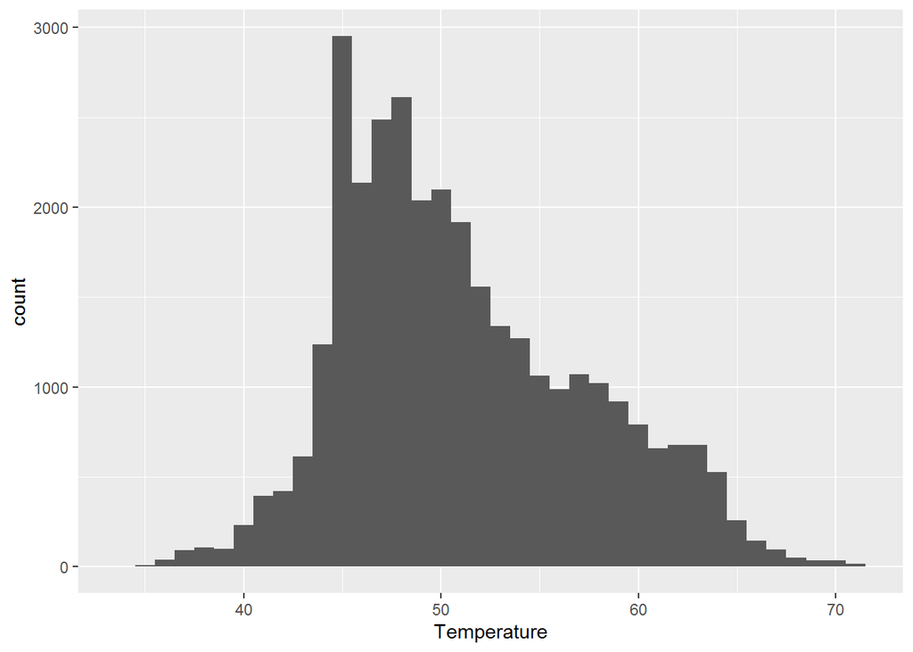

```r
library(ggplot2)
ggplot(SolarPrediction, aes(x=Temperature)) + geom_histogram(binwidth = 1)
```

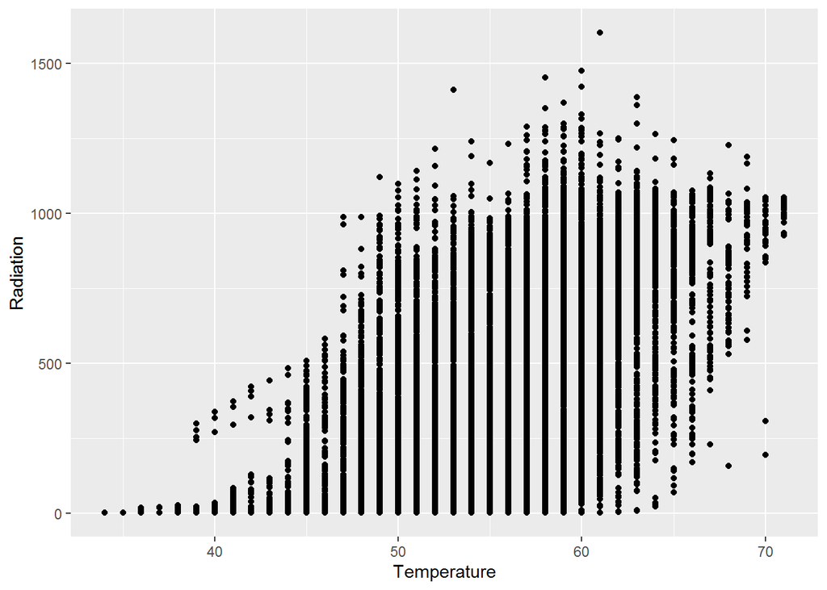

```r
ggplot(SolarPrediction, aes(x=Temperature, y=Radiation)) + geom_point()
```

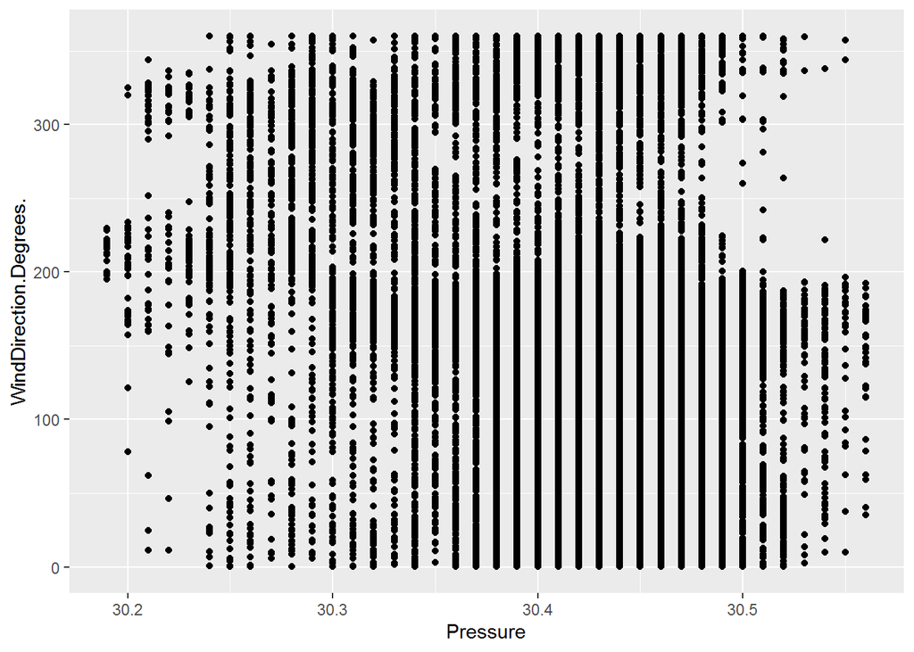

```r
ggplot(SolarPrediction, aes(x=Pressure, y=WindDirection.Degrees.)) + geom_point()
```

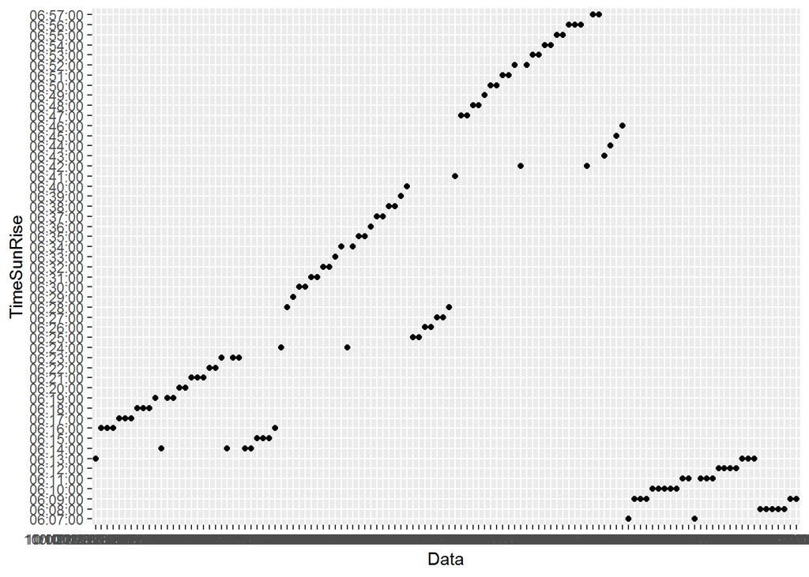

```r
ggplot(SolarPrediction, aes(x=Data, y=TimeSunRise)) + geom_point()
```

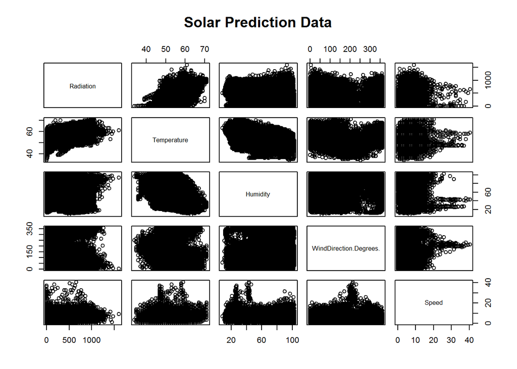

```r
pairs(~  Radiation + Temperature + Humidity + WindDirection.Degrees. + Speed, data = SolarPrediction, main = 'Solar Prediction Data')
```

## Feature correlation

```
##                          Radiation Temperature    Pressure     Humidity
## Radiation               1.00000000  0.73495476  0.11901566 -0.226170647
## Temperature             0.73495476  1.00000000  0.31117348 -0.285054954
## Pressure                0.11901566  0.31117348  1.00000000 -0.223973259
## Humidity               -0.22617065 -0.28505495 -0.22397326  1.000000000
## WindDirection.Degrees. -0.23032355 -0.25942119 -0.22900997 -0.001833315
## Speed                   0.07362687 -0.03145814 -0.08363929 -0.211623673
##                        WindDirection.Degrees.       Speed
## Radiation                        -0.230323549  0.07362687
## Temperature                      -0.259421188 -0.03145814
## Pressure                         -0.229009974 -0.08363929
## Humidity                         -0.001833315 -0.21162367
## WindDirection.Degrees.            1.000000000  0.07309242
## Speed                             0.073092422  1.00000000
```

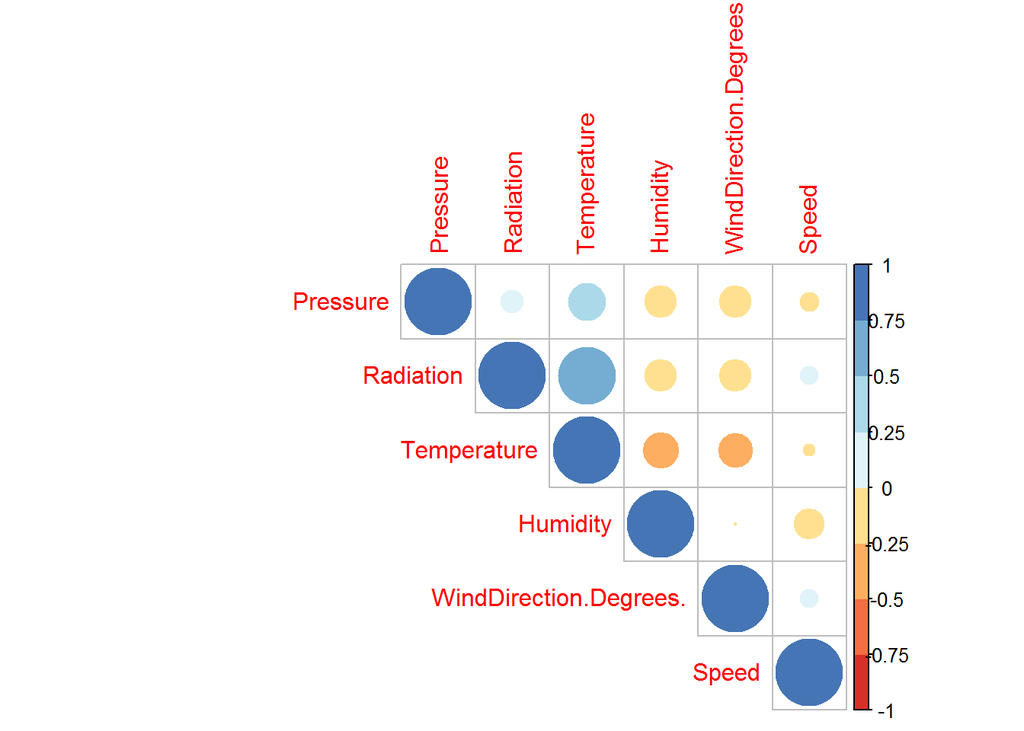

## Normalization

```
##    Radiation          Temperature        Pressure         Humidity
##  Min.   :0.0000000   Min.   :0.0000   Min.   :0.0000   Min.   :0.0000
##  1st Qu.:0.0000750   1st Qu.:0.3243   1st Qu.:0.5676   1st Qu.:0.5053
##  Median :0.0009687   Median :0.4324   Median :0.6486   Median :0.8105
##  Mean   :0.1287471   Mean   :0.4623   Mean   :0.6294   Mean   :0.7054
##  3rd Qu.:0.2206824   3rd Qu.:0.5676   3rd Qu.:0.7297   3rd Qu.:0.9368
##  Max.   :1.0000000   Max.   :1.0000   Max.   :1.0000   Max.   :1.0000
##  WindDirection.Degrees.     Speed
##  Min.   :0.0000         Min.   :0.00000
##  1st Qu.:0.2282         1st Qu.:0.08321
##  Median :0.4102         Median :0.13877
##  Mean   :0.3985         Mean   :0.15417
##  3rd Qu.:0.4980         3rd Qu.:0.19432
##  Max.   :1.0000         Max.   :1.00000
```